# Lab 3: Gesture Recognition using Convolutional Neural Networks

### Part (b) - 3 pt

Build a convolutional neural network model that takes as input these AlexNet features, and makes a prediction. Your model should be a subclass of nn.Module.

Explain your choice of neural network architecture: how many layers did you choose? What types of layers did you use: fully-connected or convolutional? What about other decisions like pooling layers, activation functions, number of channels / hidden units in each layer?

Here is an example of how your model may be called:

```python
# features = ... load precomputed alexnet.features(img) ...
#output = model(features)
#prob = F.softmax(output)
```

```python
# Since the input dimensions are 256 x 6 x 6, the convolutional kernels don't
# need to be large. I used 2 convolutional layers with 2x2 kernels. These
# filters are then fed into a 2-layer fully-connected network that performs the
# final classification. It has 50 hidden units to account for the fact that it
# does not have a third layer. I found through trial and error that having
# 3 layers resulted in overfitting and poor validation accuracy.

class ASL_AlexNet(nn.Module):
  def __init__ (self):
    super(ASL_AlexNet, self).__init__()

    self.conv1 = nn.Conv2d(256, 50, 2)
    self.conv2 = nn.Conv2d(50, 25, 2)

    self.fc1 = nn.Linear(25 * 4 * 4, 50)
    self.fc2 = nn.Linear(50, 9)

  def forward (self, x):
    x = F.relu(self.conv1(x))
    x = F.relu(self.conv2(x))

    x = x.view(-1, 25 * 4 * 4)

    x = F.relu(self.fc1(x))
    x = self.fc2(x)
    return x
```

### Part (c) - 5 pt

Train your new network, including any hyperparameter tuning. Plot and submit the training curve of your best model only.

Note: Depending on how you are caching (saving) your AlexNet features, PyTorch might still be tracking updates to the **AlexNet weights**, which we are not tuning. One workaround is to convert your AlexNet feature tensor into a numpy array, and then back into a PyTorch tensor.

```python
#tensor = torch.from_numpy(tensor.detach().numpy())
```

```
CUDA is available!  Training on GPU ...
```

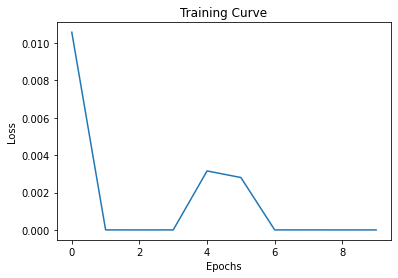

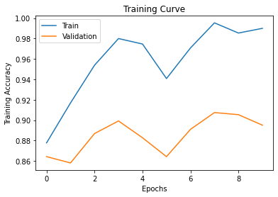

```
Final Training Accuracy: 0.99
Final Validation Accuracy: 0.8950617283950617
Total time elapsed: 77.66 seconds
```

```python
# Load the features back in
train_features = torchvision.datasets.DatasetFolder(
    '/content/gdrive/MyDrive/Colab Notebooks/Labs/Lab_3b_Features/train',
    loader=torch.load,
    extensions=('.tensor'))
val_features = torchvision.datasets.DatasetFolder(
    '/content/gdrive/MyDrive/Colab Notebooks/Labs/Lab_3b_Features/val',
    loader=torch.load,
    extensions=('.tensor'))
test_features = torchvision.datasets.DatasetFolder(
    '/content/gdrive/MyDrive/Colab Notebooks/Labs/Lab_3b_Features/test',
    loader=torch.load,
    extensions=('.tensor'))

# Generate DataLoader objects
train_f_loader = torch.utils.data.DataLoader(train_features,
                                             shuffle=True,
                                             drop_last=True)
val_f_loader = torch.utils.data.DataLoader(val_features,
                                           shuffle=True,
                                           drop_last=True)
test_f_loader = torch.utils.data.DataLoader(test_features,
                                            shuffle=True,
                                            drop_last=True)

# Create the new network
AdvancedNet = ASL_AlexNet()

if use_cuda and torch.cuda.is_available():
  AdvancedNet = AdvancedNet.cuda()

train(AdvancedNet,
      train_loader=train_f_loader,
      val_loader=val_f_loader,
      batch_size=128,
      learning_rate=0.0005)
```

### Part (d) - 2 pt

Report the test accuracy of your best model. How does the test accuracy compare to Part 3(d) without transfer learning?

```python
# The test accuracy is a higher than the test accuracy from Part 3(d).
# AlexNet, in particular, is very good at extracting important features from
# images and visual information.

if use_cuda and torch.cuda.is_available():
  AdvancedNet = AdvancedNet.cuda()

print("Test accuracy: {}".format(get_accuracy(AdvancedNet, test_f_loader)))
```

```
Test accuracy: 0.8993839835728953
```

### 5. Additional Testing [5 pt]

As a final step in testing we will be revisiting the sample images that you had collected and submitted at the start of this lab. These sample images should be untouched and will be used to demonstrate how well your model works at identifying your hand guestures.

Using the best transfer learning model developed in Part 4. Report the test accuracy on your sample images and how it compares to the test accuracy obtained in Part 4(d)? How well did your model do for the different hand guestures? Provide an explanation for why you think your model performed the way it did?

```python
# The model performed quite well. I believe that the performance was slightly
# worse than the accuracy in Part 4(d), due to the fact that the testing
# dataset for Part 4(d)'s accuracy came from the same overall dataset as the
# training and validation set. This means that the images were doctored and
# edited similarly, and included hands of the same people.

# This test dataset, however, included completely different environments,
# lighting, and people. This would bring a lot more unobserved variance and
# information, attributing to the slightly worse test accuracy.

train_loader, val_loader, test_loader = get_data_loader(
    data_path='/content/gdrive/MyDrive/Colab Notebooks/Labs/lee-1004112177',
    batch_size=1)

save_features('/content/gdrive/MyDrive/Colab Notebooks/Labs/lee-1004112177', train_loader)
submitted_features = torchvision.datasets.DatasetFolder(
    '/content/gdrive/MyDrive/Colab Notebooks/Labs/lee-1004112177',
    loader=torch.load,
    extensions=('.tensor'))

test_f_loader = torch.utils.data.DataLoader(submitted_features,
                                            drop_last=True)

print("Test accuracy: {}".format(get_accuracy(AdvancedNet, test_f_loader)))
```

```
Test accuracy: 0.875
```